# prediction_ARIMA

Add functions to load and manipulate the stocks

```python
import pandas as pd
import numpy as np
import matplotlib.pyplot as plt
import matplotlib
matplotlib.rcParams['figure.figsize'] = (15.0, 7.5)

def load_all_stocks(file):
	"""load the pre-processed stocks from the csv"""
	data=pd.read_csv(file,parse_dates=True,index_col=['t','s'])

	#replicate the time and stock column for easier access
	data['time']=data.index.get_level_values('t')
	data['stock']=data.index.get_level_values('s')

	return data

def load_one_stock(stock_data,stock_name,dropna=True):
	stock=stock_data[stock_data['stock']==stock_name]

	if dropna:
		stock=stock.dropna()

	return stock
```

Load the data and run some test to confirm it works correctly

```python
stock_data=load_all_stocks('stock_data.csv')
```

```python
stock_data.head()
```

| t | s | open_p | close_p | high_p | low_p | volume | close_rtn | sign_a | sign_b | stock | time |
| --- | --- | --- | --- | --- | --- | --- | --- | --- | --- | --- | --- |
| 2017-01-03 09:30:00 | 0 | 51.274744 | 51.024482 | 51.486503 | 50.884913 | 73726.0 | NaN | NaN | NaN | 0 | 2017-01-03 09:30:00 |
| 2017-01-03 09:45:00 | 0 | 50.611389 | 50.487200 | 50.668706 | 50.487200 | 45661.0 | -0.010530 | -0.012937 | NaN | 0 | 2017-01-03 09:45:00 |
| 2017-01-03 10:00:00 | 0 | 50.371401 | 50.223740 | 50.433324 | 50.157150 | 64689.0 | -0.005218 | -0.004742 | NaN | 0 | 2017-01-03 10:00:00 |
| 2017-01-03 10:15:00 | 0 | 50.314079 | 50.447513 | 50.485636 | 50.275955 | 30121.0 | 0.004456 | -0.001138 | NaN | 0 | 2017-01-03 10:15:00 |
| 2017-01-03 10:30:00 | 0 | 50.480861 | 50.356760 | 50.576325 | 50.356760 | 26289.0 | -0.001799 | 0.003315 | NaN | 0 | 2017-01-03 10:30:00 |

```python
stock_344=load_one_stock(stock_data,344,True)
stock_344
```

| t | s | open_p | close_p | high_p | low_p | volume | close_rtn | sign_a | sign_b | stock | time |
| --- | --- | --- | --- | --- | --- | --- | --- | --- | --- | --- | --- |
| 2017-01-03 11:45:00 | 344 | 24.061130 | 24.027519 | 24.085139 | 24.008313 | 97909.0 | 0.005858 | 0.007265 | 0.449077 | 344 | 2017-01-03 11:45:00 |
| 2017-01-03 12:00:00 | 344 | 23.708042 | 23.802798 | 23.821749 | 23.674877 | 67891.0 | -0.009353 | -0.014675 | 0.332189 | 344 | 2017-01-03 12:00:00 |
| 2017-01-03 12:15:00 | 344 | 23.778062 | 23.730714 | 23.787532 | 23.725979 | 85416.0 | -0.003028 | 0.002953 | 0.439244 | 344 | 2017-01-03 12:15:00 |
| 2017-01-03 12:30:00 | 344 | 24.044755 | 24.025565 | 24.063945 | 23.996781 | 55252.0 | 0.012425 | 0.011216 | 0.300686 | 344 | 2017-01-03 12:30:00 |
| 2017-01-03 12:45:00 | 344 | 23.801665 | 23.815920 | 23.825424 | 23.787410 | 60332.0 | -0.008726 | -0.010110 | 0.344878 | 344 | 2017-01-03 12:45:00 |
| 2017-01-03 13:00:00 | 344 | 23.611840 | 23.611840 | 23.621262 | 23.555308 | 69776.0 | -0.008569 | -0.007975 | 0.415516 | 344 | 2017-01-03 13:00:00 |
| 2017-01-03 13:15:00 | 344 | 23.622958 | 23.679495 | 23.679495 | 23.618247 | 94126.0 | 0.002865 | 0.000471 | 0.576351 | 344 | 2017-01-03 13:15:00 |
| 2017-01-03 13:30:00 | 344 | 24.092651 | 24.049491 | 24.092651 | 24.035104 | 92765.0 | 0.015625 | 0.019883 | 0.582827 | 344 | 2017-01-03 13:30:00 |
| 2017-01-03 13:45:00 | 344 | 23.887472 | 23.887472 | 23.911288 | 23.849366 | 94613.0 | -0.006737 | -0.008516 | 0.608140 | 344 | 2017-01-03 13:45:00 |
| 2017-01-03 14:00:00 | 344 | 23.892101 | 23.906391 | 23.930206 | 23.877812 | 123155.0 | 0.000792 | 0.000194 | 0.800377 | 344 | 2017-01-03 14:00:00 |
| 2017-01-03 14:15:00 | 344 | 23.812722 | 23.807978 | 23.826956 | 23.789000 | 101104.0 | -0.004117 | -0.003322 | 0.668532 | 344 | 2017-01-03 14:15:00 |
| 2017-01-03 14:30:00 | 344 | 24.003656 | 24.032369 | 24.051511 | 23.984514 | 104835.0 | 0.009425 | 0.008018 | 0.766711 | 344 | 2017-01-03 14:30:00 |
| 2017-01-03 14:45:00 | 344 | 23.956421 | 23.981891 | 24.000969 | 23.934194 | 92667.0 | -0.002100 | -0.001968 | 0.699741 | 344 | 2017-01-03 14:45:00 |
| 2017-01-03 15:00:00 | 344 | 24.143365 | 24.162573 | 24.172177 | 24.128961 | 157646.0 | 0.007534 | 0.007804 | 1.295441 | 344 | 2017-01-03 15:00:00 |
| 2017-01-03 15:15:00 | 344 | 23.985628 | 23.961800 | 23.990395 | 23.937972 | 111268.0 | -0.008309 | -0.006533 | 0.962047 | 344 | 2017-01-03 15:15:00 |
| 2017-01-03 15:30:00 | 344 | 23.985090 | 24.080496 | 24.090036 | 23.985090 | 208930.0 | 0.004954 | -0.000022 | 1.798648 | 344 | 2017-01-03 15:30:00 |
| 2017-01-03 15:45:00 | 344 | 24.059891 | 24.183812 | 24.221942 | 24.059891 | 719126.0 | 0.004290 | 0.003119 | 5.169855 | 344 | 2017-01-03 15:45:00 |
| 2017-01-04 09:30:00 | 344 | 24.264111 | 24.426062 | 24.492747 | 24.254584 | 239722.0 | 0.010017 | 0.008488 | 1.683979 | 344 | 2017-01-04 09:30:00 |
| 2017-01-04 09:45:00 | 344 | 24.290472 | 24.432577 | 24.432577 | 24.186262 | 245633.0 | 0.000267 | 0.001086 | 1.651500 | 344 | 2017-01-04 09:45:00 |
| 2017-01-04 10:00:00 | 344 | 24.763042 | 24.676626 | 24.763042 | 24.638219 | 137921.0 | 0.009989 | 0.019455 | 0.931871 | 344 | 2017-01-04 10:00:00 |
| 2017-01-04 10:15:00 | 344 | 24.685700 | 24.762543 | 24.800963 | 24.666489 | 92908.0 | 0.003482 | -0.003123 | 0.628801 | 344 | 2017-01-04 10:15:00 |
| 2017-01-04 10:30:00 | 344 | 24.440765 | 24.459726 | 24.492908 | 24.412323 | 157484.0 | -0.012229 | -0.009922 | 1.034487 | 344 | 2017-01-04 10:30:00 |
| 2017-01-04 10:45:00 | 344 | 24.353350 | 24.325031 | 24.358069 | 24.315593 | 95186.0 | -0.005507 | -0.003577 | 0.623261 | 344 | 2017-01-04 10:45:00 |
| 2017-01-04 11:00:00 | 344 | 24.615708 | 24.706436 | 24.725536 | 24.591833 | 106799.0 | 0.015679 | 0.010773 | 0.687696 | 344 | 2017-01-04 11:00:00 |
| 2017-01-04 11:15:00 | 344 | 24.418554 | 24.489346 | 24.512944 | 24.418554 | 156015.0 | -0.008787 | -0.008009 | 0.974582 | 344 | 2017-01-04 11:15:00 |
| 2017-01-04 11:30:00 | 344 | 24.760592 | 24.669912 | 24.760592 | 24.641276 | 141549.0 | 0.007373 | 0.014007 | 0.864830 | 344 | 2017-01-04 11:30:00 |
| 2017-01-04 11:45:00 | 344 | 24.378839 | 24.482579 | 24.482579 | 24.378839 | 149510.0 | -0.007594 | -0.015418 | 0.898272 | 344 | 2017-01-04 11:45:00 |
| 2017-01-04 12:00:00 | 344 | 24.622071 | 24.593617 | 24.622071 | 24.550937 | 162714.0 | 0.004535 | 0.009977 | 0.957483 | 344 | 2017-01-04 12:00:00 |
| 2017-01-04 12:15:00 | 344 | 24.694962 | 24.690200 | 24.696487 | 24.652097 | 105197.0 | 0.003927 | 0.002960 | 0.617105 | 344 | 2017-01-04 12:15:00 |
| 2017-01-04 12:30:00 | 344 | 24.810184 | 24.834104 | 24.838888 | 24.771911 | 75229.0 | 0.005828 | 0.004666 | 0.447599 | 344 | 2017-01-04 12:30:00 |
| ... | ... | ... | ... | ... | ... | ... | ... | ... | ... | ... | ... |
| 2017-12-28 15:00:00 | 344 | 23.245866 | 23.230990 | 23.255783 | 23.230990 | 106248.0 | 0.006760 | 0.007620 | 1.763987 | 344 | 2017-12-28 15:00:00 |
| 2017-12-28 15:15:00 | 344 | 23.240117 | 23.230195 | 23.245077 | 23.205393 | 426218.0 | -0.000034 | -0.000247 | 5.543138 | 344 | 2017-12-28 15:15:00 |
| 2017-12-28 15:30:00 | 344 | 22.985337 | 22.980429 | 23.019695 | 22.970613 | 297043.0 | -0.010752 | -0.010963 | 3.394424 | 344 | 2017-12-28 15:30:00 |
| 2017-12-28 15:45:00 | 344 | 23.284237 | 23.294183 | 23.299157 | 23.274291 | 283171.0 | 0.013653 | 0.013004 | 2.930497 | 344 | 2017-12-28 15:45:00 |
| 2017-12-29 09:30:00 | 344 | 23.256765 | 23.182447 | 23.306311 | 23.177492 | 117048.0 | -0.004797 | -0.001180 | 1.159790 | 344 | 2017-12-29 09:30:00 |
| 2017-12-29 09:45:00 | 344 | 23.286194 | 23.355854 | 23.355854 | 23.236438 | 140507.0 | 0.007480 | 0.001265 | 1.351729 | 344 | 2017-12-29 09:45:00 |
| 2017-12-29 10:00:00 | 344 | 23.085103 | 23.153955 | 23.163791 | 23.075267 | 124279.0 | -0.008644 | -0.008636 | 1.144658 | 344 | 2017-12-29 10:00:00 |
| 2017-12-29 10:15:00 | 344 | 23.082350 | 23.057841 | 23.082350 | 23.038234 | 143097.0 | -0.004151 | -0.000119 | 1.255274 | 344 | 2017-12-29 10:15:00 |
| 2017-12-29 10:30:00 | 344 | 23.197643 | 23.118706 | 23.207510 | 23.118706 | 229774.0 | 0.002640 | 0.004995 | 1.850236 | 344 | 2017-12-29 10:30:00 |
| 2017-12-29 10:45:00 | 344 | 23.384947 | 23.374965 | 23.399917 | 23.374965 | 225460.0 | 0.011084 | 0.008074 | 1.733248 | 344 | 2017-12-29 10:45:00 |
| 2017-12-29 11:00:00 | 344 | 23.368619 | 23.348663 | 23.388575 | 23.338685 | 251575.0 | -0.001125 | -0.000698 | 1.779280 | 344 | 2017-12-29 11:00:00 |
| 2017-12-29 11:15:00 | 344 | 23.252858 | 23.262795 | 23.262795 | 23.242921 | 85925.0 | -0.003678 | -0.004954 | 0.598436 | 344 | 2017-12-29 11:15:00 |
| 2017-12-29 11:30:00 | 344 | 22.989386 | 22.979664 | 22.989484 | 22.969844 | 105778.0 | -0.012171 | -0.011331 | 0.714384 | 344 | 2017-12-29 11:30:00 |
| 2017-12-29 11:45:00 | 344 | 23.005419 | 23.000505 | 23.015246 | 22.990678 | 236808.0 | 0.000907 | 0.000697 | 1.490566 | 344 | 2017-12-29 11:45:00 |
| 2017-12-29 12:00:00 | 344 | 23.373902 | 23.418832 | 23.423825 | 23.363917 | 197088.0 | 0.018188 | 0.016017 | 1.194907 | 344 | 2017-12-29 12:00:00 |
| 2017-12-29 12:15:00 | 344 | 23.264123 | 23.221969 | 23.264123 | 23.209571 | 127769.0 | -0.008406 | -0.004697 | 0.752852 | 344 | 2017-12-29 12:15:00 |
| 2017-12-29 12:30:00 | 344 | 23.112384 | 23.092647 | 23.122253 | 23.092647 | 109162.0 | -0.005569 | -0.006522 | 0.637723 | 344 | 2017-12-29 12:30:00 |
| 2017-12-29 12:45:00 | 344 | 23.179553 | 23.189459 | 23.199364 | 23.179553 | 40034.0 | 0.004192 | 0.002906 | 0.234147 | 344 | 2017-12-29 12:45:00 |
| 2017-12-29 13:00:00 | 344 | 23.134612 | 23.124730 | 23.144494 | 23.124730 | 43081.0 | -0.002791 | -0.001939 | 0.251343 | 344 | 2017-12-29 13:00:00 |
| 2017-12-29 13:15:00 | 344 | 23.280435 | 23.280435 | 23.290379 | 23.270491 | 47748.0 | 0.006733 | 0.006303 | 0.286104 | 344 | 2017-12-29 13:15:00 |
| 2017-12-29 13:30:00 | 344 | 22.983972 | 22.983972 | 22.983972 | 22.974159 | 17459.0 | -0.012734 | -0.012734 | 0.107472 | 344 | 2017-12-29 13:30:00 |
| 2017-12-29 13:45:00 | 344 | 23.309659 | 23.299702 | 23.319616 | 23.279787 | 98473.0 | 0.013737 | 0.014170 | 0.674177 | 344 | 2017-12-29 13:45:00 |
| 2017-12-29 14:00:00 | 344 | 23.014452 | 23.023304 | 23.024287 | 23.014452 | 11444.0 | -0.011863 | -0.012665 | 0.086839 | 344 | 2017-12-29 14:00:00 |
| 2017-12-29 14:15:00 | 344 | 23.065577 | 23.055724 | 23.070503 | 23.036018 | 87570.0 | 0.001408 | 0.002221 | 0.717764 | 344 | 2017-12-29 14:15:00 |
| 2017-12-29 14:30:00 | 344 | 23.355434 | 23.360424 | 23.385377 | 23.345453 | 56422.0 | 0.013216 | 0.012567 | 0.474243 | 344 | 2017-12-29 14:30:00 |
| 2017-12-29 14:45:00 | 344 | 23.211849 | 23.231688 | 23.236649 | 23.182090 | 66170.0 | -0.005511 | -0.006148 | 0.574114 | 344 | 2017-12-29 14:45:00 |
| 2017-12-29 15:00:00 | 344 | 22.966213 | 22.971118 | 22.995645 | 22.946593 | 48565.0 | -0.011216 | -0.010582 | 0.435677 | 344 | 2017-12-29 15:00:00 |
| 2017-12-29 15:15:00 | 344 | 23.351793 | 23.346807 | 23.371740 | 23.326861 | 48453.0 | 0.016355 | 0.016789 | 0.453944 | 344 | 2017-12-29 15:15:00 |
| 2017-12-29 15:30:00 | 344 | 23.034710 | 22.995352 | 23.039630 | 22.995352 | 125457.0 | -0.015054 | -0.013579 | 1.235761 | 344 | 2017-12-29 15:30:00 |
| 2017-12-29 15:45:00 | 344 | 22.915025 | 22.929734 | 23.017981 | 22.915025 | 704595.0 | -0.002854 | -0.005196 | 5.615251 | 344 | 2017-12-29 15:45:00 |

6493 rows × 10 columns

Define the functions used for ARIMA prediction.

More details on what functions are needed.

```python
import itertools
import warnings
from statsmodels.api import tsa
from statsmodels.tsa.stattools import acf, pacf
from statsmodels.tsa.arima_model import ARIMA
from sklearn.metrics import mean_squared_error as mse

warnings.filterwarnings("ignore")

def find_params_arima_grid_search(series,p,d,q):
    """This function derives the parameters p and q for ARIMA algorithm.

    Given the error margin is +/- 1.96*std, p and q take the value of the point where
    the acf and pacf cross the horizontal error margin the first time
    """
    pdq = list(itertools.product(p, d, q))
    best_params=pdq[0]
    smallest_aic=float("inf")

    for params in pdq:
        try:
            #the time series is already stationary
            model= tsa.statespace.SARIMAX(series.values, order=params)

            results = model.fit()
            if results.aic<smallest_aic:
                smallest_aic=results.aic
                best_params=params
        except Exception as e:
            continue

    return best_params

def find_params_arima_acf_pacf(shifted_series, nlags=20):
    """This function derives the parameters p and q for ARIMA algorithm.

    Given the error margin is +/- 1.96*std, p and q take the value of the point where
    the acf and pacf cross the horizontal error margin the first time
    """
    lag_acf = acf(shifted_series, nlags=nlags)
    lag_pacf = pacf(shifted_series, nlags=nlags, method='ols')

    # p is the point where the pacf cross the error margin the first time
    p = np.argmax(lag_acf < -1.96 / np.sqrt(len(shifted_series)))

    # q is the point where the acf cross the error margin the first time
    q = np.argmax(lag_pacf < -1.96 / np.sqrt(len(shifted_series)))

    return p, q


def predict_stock(stock_close_rtn, n_steps=5, plot=False):
    """Given the close returns of a stock (as a dataframe), predict the next n_step values"""
    diff_series = (stock_close_rtn - stock_close_rtn.shift()).dropna()
    p, q = find_params_arima(diff_series)

    model = ARIMA(stock_close_rtn.values, (p, q, 0)).fit(disp=plot)
    predicted = model.predict(end=n_steps)

    if plot:
        model.plot_predict(len(stock_close_rtn) - 10, len(stock_close_rtn) + n_steps)
    plt.axhline(y=0, linestyle='--', color='gray')

    return predicted


def evaluate_prediction_for_stock(stock_close_rtn, split=0.7):
    """Split the stock close returns into training (70%) and test set (30%)
    Train ARIMA on the training set, perform predict on the test set, and compute
    RMSE to evaluate the performance of the model

    return: the model, predicted values and RMSE
    """

    total_length = stock_close_rtn.shape[0]
    split_point = int(np.ceil(total_length * split))
    training_set = stock_close_rtn.iloc[:split_point]
    test_set = stock_close_rtn.iloc[split_point:]

    # get the p, q values
    diff_series = (stock_close_rtn - stock_close_rtn.shift()).dropna()
    #p, q = find_params_arima(diff_series)
    p, q = find_params_arima_acf_pacf(diff_series)

    model = ARIMA(training_set.values, (p, q, 0)).fit()

    predicted = model.predict(end=len(test_set))

    rmse = np.sqrt(mse(test_set.values, predicted))

    return predicted, rmse
```

Another function to search for parameters of ARIMA was introduced above. The function makes use of ACF and PACF to find the parameters in a more efficient (and less exhaustive way)

Now let's test the function with one stock. Let's test with different size of training and test sets

```python
stock_250=load_one_stock(stock_data,250,dropna=True)
stock_250.index=stock_250['time']
STEP=0.05
for i in range(5):
    predicted,rmse=evaluate_prediction_for_stock(stock_250['close_rtn'].loc['2017-04-06':'2017-04-30'],split=0.6+i*STEP)
    print(rmse)
#stock_250['close_rtn'].loc['2017-04-06':'2017-04-30']
```

```
0.012265400928254512
0.013166106336722973
0.013265861654473615
0.012991606294997116
0.01361383215319705
```

It is a good sign that the values of RMSE do not vary much. Let's perform actual prediction of close returns in the future. In this future, the prediction is made for the next 2 hours (8 steps ahead)

```
[ 0.00015748 -0.00047109 -0.00041993 -0.00657993  0.01625279 -0.00799106
 -0.01006789  0.0086727 ]
```

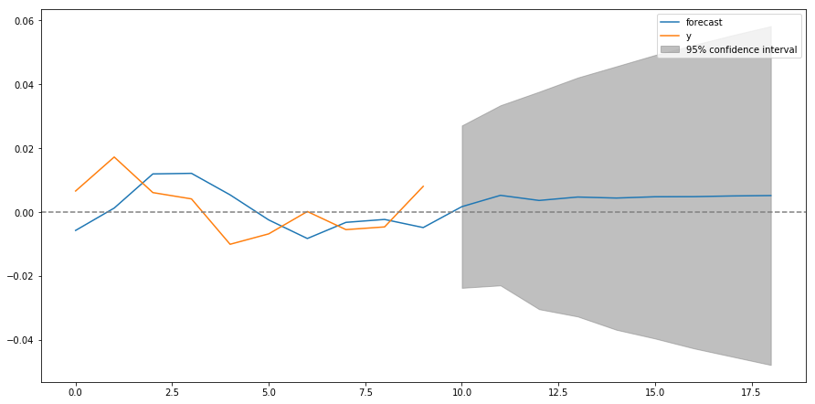

```python
predicted=predict_stock(stock_250['close_rtn'].loc['2017-04-08':'2017-04-10'],n_steps=8,plot=True)
print(predicted)
```

Now it's time to evaluate the prediction on all the stocks

```python
all_rmse={}
problematic_stocks=[]
for stock_name in np.unique(stock_data['stock'].values):
    try:
        stock=load_one_stock(stock_data,stock_name,True)
        predicted,rmse=evaluate_prediction_for_stock(stock['close_rtn'],split=0.7)
        all_rmse[stock_name]=rmse
    except ValueError:
        print("Something wrong with "+str(stock_name))
        problematic_stocks.append(stock_name)
rmse_vals=np.array(list(all_rmse.values()))
```

```
Something wrong with 98
Something wrong with 149
Something wrong with 168
Something wrong with 247
Something wrong with 442
Something wrong with 482
Something wrong with 556
Something wrong with 585
Something wrong with 588
Something wrong with 593
Something wrong with 713
Something wrong with 741
Something wrong with 926
Something wrong with 931
Something wrong with 942
Something wrong with 956
Something wrong with 972
Something wrong with 994
```

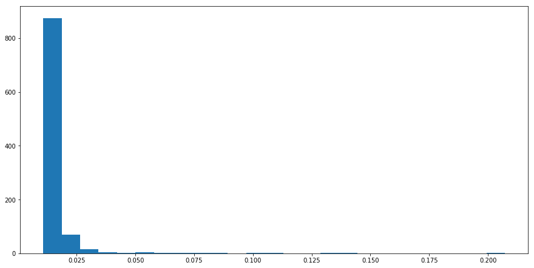

```python
plt.hist(rmse_vals,bins=25)
```

```python
# Check what's wrong with the stocks that throw errors.
# It looks like the data of those stocks are empty or very scarced after NaNs are removed
for stock_name in problematic_stocks:
    stock=load_one_stock(stock_data,stock_name,True)
    print(stock.shape)
```

```
(0, 10)
(0, 10)
(0, 10)
(10, 10)
(5, 10)
(7, 10)
(0, 10)
(6, 10)
(21, 10)
(10, 10)
(9, 10)
(3, 10)
(0, 10)
(17, 10)
(4, 10)
(0, 10)
(9, 10)
(0, 10)
```

Something might not be right. The close returns (in 15 min interval) of the previous month probably won't affect the close returns now. It will be good to split the data in greater granularity into smaller training/test sets and evaluate the performace of the same model. This is to replicate the effect of cross validation, which is not applicable to time series (the predicted values lag behind)